# Diagnostic atlas of variation

# Introduction

Manipulating excel data in R can be difficult because often excel spreadsheets combine data storage, presentation and analysis in the same sheets and can be heavly formattted (merged columns, multiple column headers, multiple tables per sheet). The Atlas of Variation is an exampleof ‘messy data’.

- Messy data - multiple sheets, variable formatting, variable field names

The objective is to extract CCG and other data to: + Put in PHOLIO format + New anlaysis

To do this we need to manipulate the data into tidy format.

Now new `R` tools for manipulating excel sheets - see https://www.r-bloggers.com/how-to-use-jailbreakr/ which we will use to reorganise the spreadsheets and prepare the data for analysis.

## Data wrangling

Start by loading libraries.

and download the data from the [Fingertips website](https://fingertips.phe.org.uk/profile/atlas-of-variation).

```r
url <- "https://fingertips.phe.org.uk/documents/DiagAtlasData_291116.xlsx"
destfile <- "aov_diag.xlsx"
aov_diag <- download.file(url, destfile)
```

```r
workbook <- rexcel_read_workbook("aov_diag.xlsx", progress = FALSE)
sheet_names <- names(workbook$sheets) ## these are the sheet names
```

Let’s look at sheet 1 to see what the structure is. The `jailbreakr` package has a `split_sheet` function, which extracts tables from the sheet.

```r
glimpse(tables)
```

```
List of 4
 $ :Classes 'worksheet_view', 'R6' <worksheet_view>
  Public:
    cells: active binding
    clone: function (deep = FALSE)
    data: NULL
    dim: 2 2
    header: NULL
    idx: list
    initialize: function (sheet, xr, filter, header, data)
    lookup: active binding
    lookup2: active binding
    merged: active binding
    sheet: worksheet, R6
    table: function (col_names = TRUE, ...)
    values: function ()
    xr: cell_limits, list
 $ :Classes 'worksheet_view', 'R6' <worksheet_view>
  Public:
    cells: active binding
    clone: function (deep = FALSE)
    data: NULL
    dim: 1051 15
    header: NULL
    idx: list
    initialize: function (sheet, xr, filter, header, data)
    lookup: active binding
    lookup2: active binding
    merged: active binding
    sheet: worksheet, R6
    table: function (col_names = TRUE, ...)
    values: function ()
    xr: cell_limits, list
 $ :Classes 'worksheet_view', 'R6' <worksheet_view>
  Public:
    cells: active binding
    clone: function (deep = FALSE)
    data: NULL
    dim: 1050 15
    header: NULL
```

[output cut: 10 more lines]

```
  Public:
    cells: active binding
    clone: function (deep = FALSE)
    data: NULL
    dim: 1050 15
    header: NULL
    idx: list
    initialize: function (sheet, xr, filter, header, data)
    lookup: active binding
    lookup2: active binding
    merged: active binding
    sheet: worksheet, R6
    table: function (col_names = TRUE, ...)
    values: function ()
    xr: cell_limits, list
```

| Period | CCG code | CCG name | Rate | 95% lower | 95% upper | 99.8% lower | 99.8% upper | Sigband | map |
| --- | --- | --- | --- | --- | --- | --- | --- | --- | --- |
| 2013/14 | E92000001 | ENGLAND | 18.27 | 18.24 | 18.31 | 18.22 | 18.33 | NA | Map 1: Rate of computed axial tomography (CT) activity per weighted population by CCG |
| 2013/14 | E38000212 | NHS Newcastle Gateshead CCG | 15.50 | 15.17 | 15.84 | 14.98 | 16.03 | 5 | Map 1: Rate of computed axial tomography (CT) activity per weighted population by CCG |
| 2013/14 | E38000042 | NHS Darlington | 16.72 | 15.99 | 17.48 | 15.57 | 17.93 | 5 | Map 1: Rate of computed axial tomography (CT) activity per weighted population by CCG |
| 2013/14 | E38000047 | NHS Durham Dales, Easington and Sedgefield | 17.14 | 16.70 | 17.59 | 16.45 | 17.85 | 5 | Map 1: Rate of computed axial tomography (CT) activity per weighted population by CCG |
| 2013/14 | E38000116 | NHS North Durham | 31.26 | 30.59 | 31.93 | 30.21 | 32.33 | 1 | Map 1: Rate of computed axial tomography (CT) activity per weighted population by CCG |
| 2013/14 | E38000075 | NHS Hartlepool and Stockton-on-Tees | 22.58 | 22.06 | 23.10 | 21.77 | 23.41 | 1 | Map 1: Rate of computed axial tomography (CT) activity per weighted population by CCG |
| 2013/14 | E38000130 | NHS Northumberland | 4.25 | 4.04 | 4.47 | 3.92 | 4.60 | 5 | Map 1: Rate of computed axial tomography (CT) activity per weighted population by CCG |
| 2013/14 | E38000162 | NHS South Tees | 23.05 | 22.54 | 23.58 | 22.24 | 23.88 | 1 | Map 1: Rate of computed axial tomography (CT) activity per weighted population by CCG |
| 2013/14 | E38000163 | NHS South Tyneside | 14.68 | 14.13 | 15.25 | 13.82 | 15.58 | 5 | Map 1: Rate of computed axial tomography (CT) activity per weighted population by CCG |
| 2013/14 | E38000176 | NHS Sunderland | 17.02 | 16.58 | 17.47 | 16.33 | 17.74 | 5 | Map 1: Rate of computed axial tomography (CT) activity per weighted population by CCG |

[output cut: 990 more lines]

#### Simple analysis

Now we have a data frame for the first map which we can further analyse…

For example plotting data over time. We have quarterly and full year data - lets just plot the quarterly data.

This suggests that:

```r
library(govstyle)
## which CCG has highest rate?
map1 %>%
  filter(stringr::str_detect(Period, "Q" )) %>%   ## identifies quarterly data
  group_by(Period) %>%
  top_n(wt = Rate, 1)
```

| Period | CCG code | CCG name | Rate | 95% lower | 95% upper | 99.8% lower | 99.8% upper | Sigband | map |
| --- | --- | --- | --- | --- | --- | --- | --- | --- | --- |
| 2013/14_Q1 | E38000173 | NHS Stafford and Surrounds | 45.8 | 44.7 | 47.0 | 44.0 | 47.6 | 1 | Map 1: Rate of computed axial tomography (CT) activity per weighted population by CCG |
| 2013/14_Q2 | E38000173 | NHS Stafford and Surrounds | 45.1 | 43.9 | 46.2 | 43.3 | 46.9 | 1 | Map 1: Rate of computed axial tomography (CT) activity per weighted population by CCG |
| 2013/14_Q3 | E38000173 | NHS Stafford and Surrounds | 48.7 | 47.6 | 49.9 | 46.9 | 50.6 | 1 | Map 1: Rate of computed axial tomography (CT) activity per weighted population by CCG |
| 2013/14_Q4 | E38000173 | NHS Stafford and Surrounds | 50.2 | 49.0 | 51.4 | 48.3 | 52.1 | 1 | Map 1: Rate of computed axial tomography (CT) activity per weighted population by CCG |
| 2014/15_Q1 | E38000173 | NHS Stafford and Surrounds | 52.3 | 51.1 | 53.5 | 50.4 | 54.3 | 1 | Map 1: Rate of computed axial tomography (CT) activity per weighted population by CCG |
| 2014/15_Q2 | E38000173 | NHS Stafford and Surrounds | 54.6 | 53.4 | 55.9 | 52.7 | 56.6 | 1 | Map 1: Rate of computed axial tomography (CT) activity per weighted population by CCG |
| 2014/15_Q3 | E38000173 | NHS Stafford and Surrounds | 47.7 | 46.5 | 48.8 | 45.9 | 49.5 | 1 | Map 1: Rate of computed axial tomography (CT) activity per weighted population by CCG |
| 2014/15_Q4 | E38000122 | NHS North Lincolnshire | 40.1 | 39.1 | 41.0 | 38.6 | 41.6 | 1 | Map 1: Rate of computed axial tomography (CT) activity per weighted population by CCG |
| 2015/16_Q1 | E38000122 | NHS North Lincolnshire | 40.3 | 39.4 | 41.2 | 38.8 | 41.8 | 1 | Map 1: Rate of computed axial tomography (CT) activity per weighted population by CCG |
| 2015/16_Q2 | E38000183 | NHS Telford & Wrekin | 43.1 | 42.1 | 44.1 | 41.5 | 44.7 | 1 | Map 1: Rate of computed axial tomography (CT) activity per weighted population by CCG |

[output cut: 2 more lines]

[figure not shown]

```r
map1 %>%
  filter(stringr::str_detect(Period, "Q" )) %>%   ## identifies quarterly data
  ggplot(aes(Period, Rate)) +
  geom_boxplot(fill = "#006435") +
  theme_gov() +
  theme(axis.text.x = element_text(angle = 45, hjust = 1)) +
  labs(title =stringr::str_wrap(paste0(title1), 50))
```

#### Mapping the data

We can map these data - a quick way is to read the GeoJSON files from the [ONS Geography Portal](http://geoportal.statistics.gov.uk/datasets/1bc1e6a77cdd4b3a9a0458b64af1ade4_2) and plot with `tmap` package.

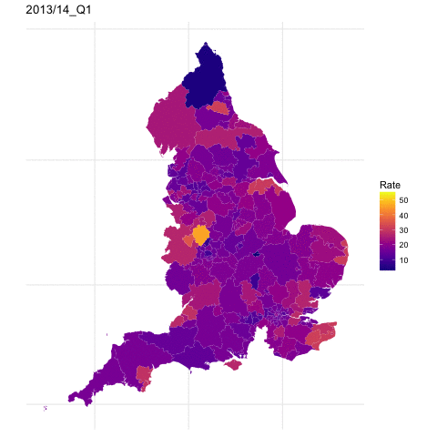

## Scaling up

Now we have a method for extracting the data we can (try) to extract each table and combine the CCG data so we can look at the interrelationships between diagnostic tests. [I am doing this sheet by sheet but could be done programmatically altough there are several differnt patterns].

| Period | CCG code | CCG name | Rate | 95% lower | 95% upper | 99.8% lower | 99.8% upper | Sigband | map |
| --- | --- | --- | --- | --- | --- | --- | --- | --- | --- |
| 2013/14_Q1 | E92000001 | ENGLAND | 18.3 | 18.2 | 18.3 | 18.2 | 18.3 | NA | Map 1: Rate of computed axial tomography (CT) activity per weighted population by CCG |
| 2013/14_Q1 | E38000212 | NHS Newcastle Gateshead CCG | 15.5 | 15.2 | 15.8 | 15.0 | 16.0 | 5 | Map 1: Rate of computed axial tomography (CT) activity per weighted population by CCG |
| 2013/14_Q1 | E38000042 | NHS Darlington | 16.7 | 16.0 | 17.5 | 15.6 | 17.9 | 5 | Map 1: Rate of computed axial tomography (CT) activity per weighted population by CCG |
| 2013/14_Q1 | E38000047 | NHS Durham Dales, Easington and Sedgefield | 17.1 | 16.7 | 17.6 | 16.5 | 17.8 | 5 | Map 1: Rate of computed axial tomography (CT) activity per weighted population by CCG |
| 2013/14_Q1 | E38000116 | NHS North Durham | 31.3 | 30.6 | 31.9 | 30.2 | 32.3 | 1 | Map 1: Rate of computed axial tomography (CT) activity per weighted population by CCG |
| 2013/14_Q1 | E38000075 | NHS Hartlepool and Stockton-on-Tees | 22.6 | 22.1 | 23.1 | 21.8 | 23.4 | 1 | Map 1: Rate of computed axial tomography (CT) activity per weighted population by CCG |

After much effort we now have a data frame of the CCG data. There are several different sets of time periods. These will need to be recoded. We have quarterly, annual and three yearly data.

```r
summary(map_all)
```

```
    Period            CCG code           CCG name              Rate       95% lower
 Length:37139       Length:37139       Length:37139       Min.   : -1   Min.   : -1.0
 Class :character   Class :character   Class :character   1st Qu.:  2   1st Qu.:  2.1
 Mode  :character   Mode  :character   Mode  :character   Median : 18   Median : 17.0
                                                          Mean   : 35   Mean   : 33.4
                                                          3rd Qu.: 48   3rd Qu.: 45.2
                                                          Max.   :328   Max.   :297.6

   95% upper    99.8% lower     99.8% upper     Sigband         map
 Min.   : -1   Min.   : -1.0   Min.   : -1   Min.   :-1.0   Length:37139
 1st Qu.:  3   1st Qu.:  2.0   1st Qu.:  3   1st Qu.: 1.0   Class :character
 Median : 18   Median : 16.6   Median : 19   Median : 3.0   Mode  :character
 Mean   : 37   Mean   : 32.3   Mean   : 39   Mean   : 3.2
 3rd Qu.: 50   3rd Qu.: 43.7   3rd Qu.: 51   3rd Qu.: 5.0
 Max.   :361   Max.   :280.9   Max.   :381   Max.   : 5.0
                                             NA's   :120
```